# Flight Price Prediction

**Importing the required libraries & packages**

```python
import numpy as np
import pandas as pd
import matplotlib.pyplot as plt
from chart_studio.plotly import plot,iplot
import cufflinks as cf
import seaborn as sns
%matplotlib inline
import os
import pickle
import ydata_profiling as pf
from sklearn.ensemble import ExtraTreesRegressor
from sklearn.model_selection import train_test_split,RandomizedSearchCV
from sklearn.ensemble import RandomForestRegressor
from sklearn.metrics import r2_score,mean_absolute_error,mean_squared_error
from catboost import CatBoostRegressor
from lightgbm import LGBMRegressor
from xgboost import XGBRegressor
import warnings
warnings.filterwarnings('ignore')
```

**Changing The Default Working Directory Path & Reading the Dataset using Pandas Command**

```python
os.chdir('C:\\Users\\Shridhar\\OneDrive\\Desktop\\Top Mentor\\Batch 74 Day 38\\Project 12 Flight Price Predict Heroku')
df=pd.read_excel('Data_Train.xlsx')
```

_**Automated Exploratory Data Analysis (EDA) with ydata_profiling(pandas_profiling)**_

```python
display(pf.ProfileReport(df))
```

[interactive chart not shown]

## Data Cleaning:

**Dropping all the null values from the dataset**

```python
df.dropna(how='any',inplace=True)
```

```python
df.isna().sum()
```

```
Airline            0
Date_of_Journey    0
Source             0
Destination        0
Route              0
Dep_Time           0
Arrival_Time       0
Duration           0
Total_Stops        0
Additional_Info    0
Price              0
dtype: int64
```

**Changing the Data Types to DataTime format using Pandas command**

```python
df['Date_of_Journey']=pd.to_datetime(df['Date_of_Journey'])
```

**Adding two new columns by seperating the day and month from the Date of Journey column**

```python
df['Day_of_Journey']=(df['Date_of_Journey']).dt.day
df['Month_of_Journey']=(df['Date_of_Journey']).dt.month
```

**Dropping the Date of Journey column since we extracted both day and month sepeartely to new column**

```python
df.drop(['Date_of_Journey'],axis=1,inplace=True)
```

**Changing the Data Types to DataTime format using Pandas command and Adding two new columns by seperating the hour and minutes from the Departure Time column**

```python
df['Dep_hr']=pd.to_datetime(df['Dep_Time']).dt.hour
df['Dep_min']=pd.to_datetime(df['Dep_Time']).dt.minute
```

**Dropping the Departure Time column since we extracted both hour and minutes sepeartely to new column**

```python
df.drop(['Dep_Time'],axis=1,inplace=True)
```

**Changing the Data Types to DataTime format using Pandas command and Adding two new columns by seperating the hour and minutes from the Arrival Time column**

```python
df['Arrival_hr']=pd.to_datetime(df['Arrival_Time']).dt.hour
df['Arrival_min']=pd.to_datetime(df['Arrival_Time']).dt.minute
```

**Dropping the Arrival Time column since we extracted both hour and minutes sepeartely to new column**

```python
df.drop(['Arrival_Time'],axis=1,inplace=True)
```

**Assigning the new variable and splitting hour and minutes and extracting it from the Duration column**

```python
duration=df['Duration'].str.split(' ',expand=True)
```

**Filling out the null values to 00 minutes to the minutes column of the assigned new variable**

```python
duration[1].fillna('00m',inplace=True)
```

**Adding two new columns with the duration hour and duration minutes from the assigned new variable columns**

```python
df['duration_hr']=duration[0].apply(lambda x:x[:-1])
df['duration_min']=duration[1].apply(lambda x:x[:-1])
```

**Dropping the Duration column since we extracted both hour and minutes sepeartely to new column**

```python
df.drop(['Duration'],axis=1,inplace=True)
```

**Grouping by the unique values from the Total Stops column**

```python
df.groupby('Total_Stops').size()
```

```
Total_Stops
1 stop      5625
2 stops     1520
3 stops       45
4 stops        1
non-stop    3491
dtype: int64
```

## Data Visualization:

**Setting the configuration file and plotting the bar graph with Airlines and its average price; and saving the PNG file**

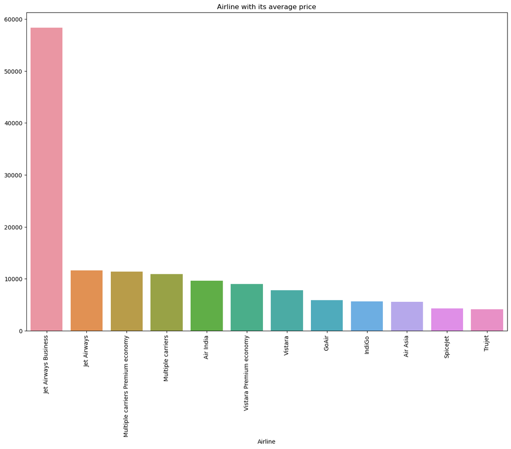

```python
cf.set_config_file(theme='ggplot',sharing='public',offline=True)
Airprices=df.groupby('Airline')['Price'].mean().sort_values(ascending=False)
plt.figure(figsize=(15,10))
sns.barplot(x=Airprices.index,y=Airprices.values)
plt.xticks(rotation=90)
plt.title('Airline with its average price')
plt.savefig('Airline with its average price.png')
plt.show()
```

**Plotting the box plot with Airlines and its price; and saving the PNG file**

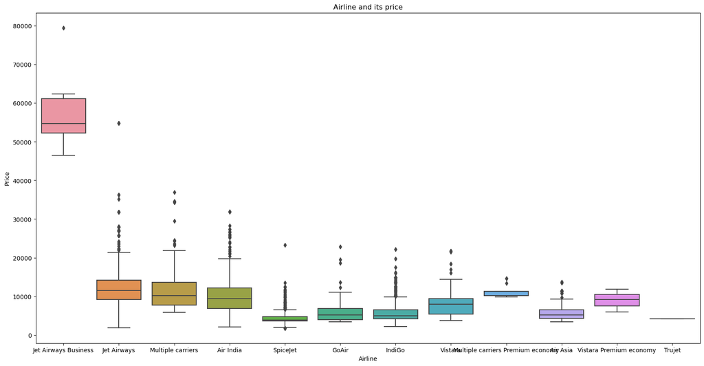

```python
plt.figure(figsize=(20,10))
sns.boxplot(y='Price',x='Airline',data= df.sort_values('Price',ascending=False))
plt.title('Airline and its price')
plt.savefig('Airline and its price.png')
plt.show()
```

**Plotting the bar graph with Airlines its price and Total Stops; and saving the PNG file**

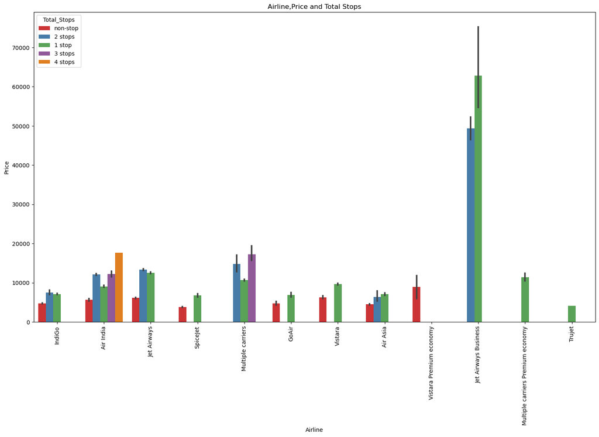

```python
plt.figure(figsize=(18,10))
ax=sns.barplot(x=df['Airline'],y=df['Price'],hue=df['Total_Stops'],palette="Set1")
ax.set_xticklabels(ax.get_xticklabels(),rotation=90)
plt.title('Airline,Price and Total Stops')
plt.savefig('Airline,Price and Total Stops.png')
plt.show()
```

**Plotting the bar graph with Source and Price and saving the png file**

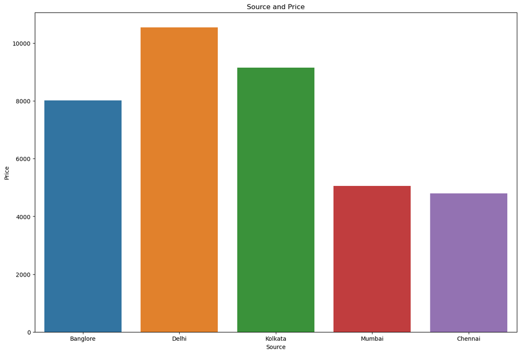

```python
plt.figure(figsize=(15,10))
sns.barplot(y='Price',x='Source',ci=None,data=df.sort_values('Price',ascending=False))
plt.title('Source and Price')
plt.savefig('Source and Price.png')
plt.show()
```

**Plotting the bar graph with Destination and Price and saving the png file**

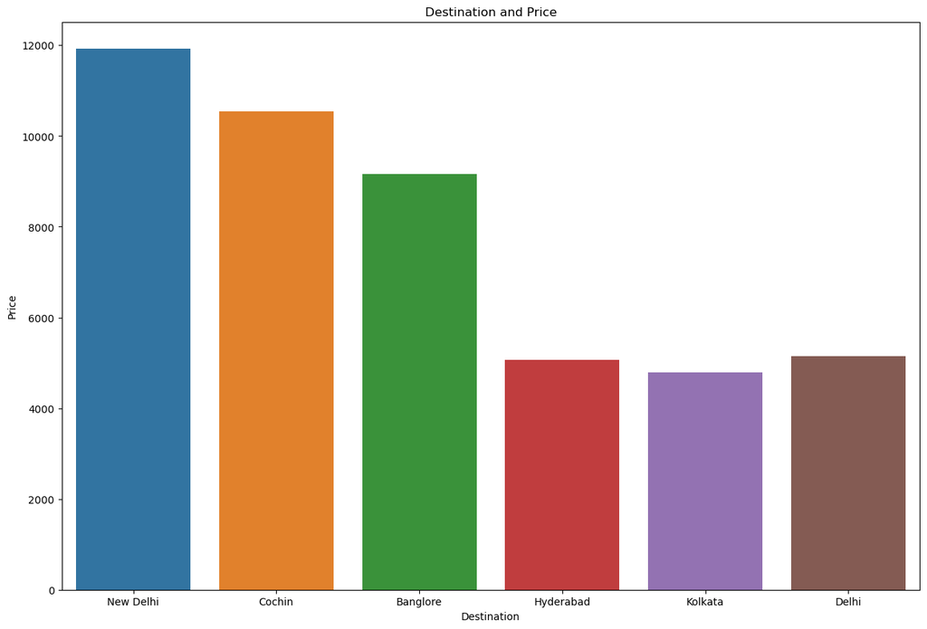

```python
plt.figure(figsize=(15,10))
sns.barplot(y='Price',x='Destination',ci=None,data=df.sort_values('Price',ascending=False))
plt.title('Destination and Price')
plt.savefig('Destination and Price.png')
plt.show()
```

**Renaming the same cities under single name from the Destination column**

```python
df['Destination']=df['Destination'].apply(lambda x:x.replace('New Delhi','Delhi'))
```

**Checking the city names of the Destination column after renaming it**

```python
df['Destination'].unique()
```

```
array(['Delhi', 'Banglore', 'Cochin', 'Kolkata', 'Hyderabad'],
      dtype=object)
```

**Plotting the bar graph again with Renamed Destination and Price and saving the png file**

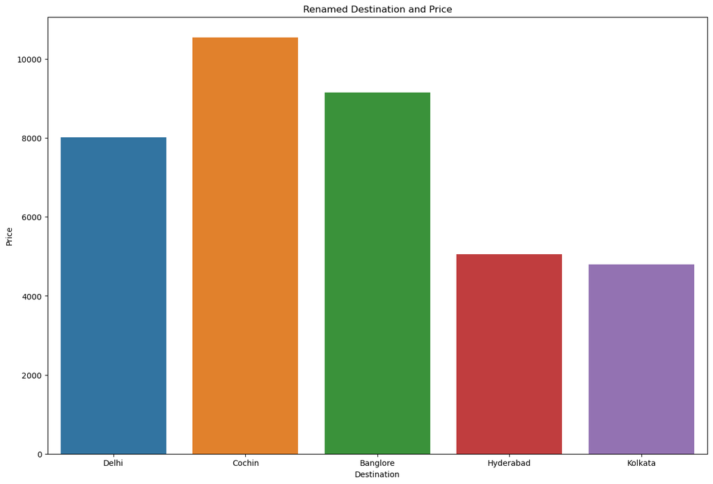

```python
plt.figure(figsize=(15,10))
sns.barplot(y='Price',x='Destination',ci=None,data=df.sort_values('Price',ascending=False))
plt.title('Renamed Destination and Price')
plt.savefig('Renamed Destination and Price.png')
plt.show()
```

**Getting the Correlation Values from all the numeric columns from the dataset using Seaborn Heatmap & saving the PNG File**

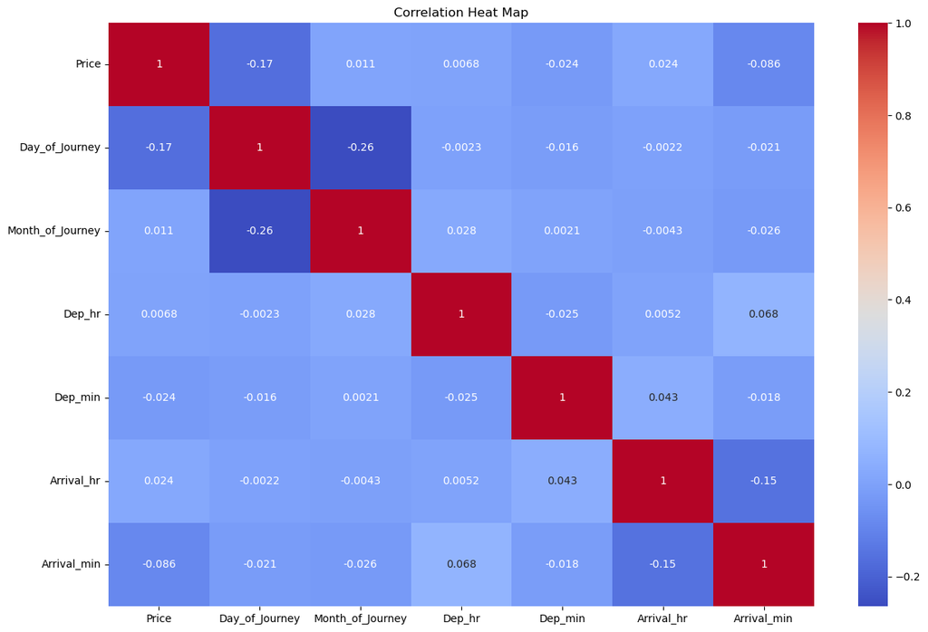

```python
plt.figure(figsize=(15,10))
sns.heatmap(df.corr(),annot=True,cmap='coolwarm')
plt.title('Correlation Heat Map')
plt.savefig('Correlation Heat Map.png')
plt.show()
```

**Label Encoding the Total stops columns using mapping function**

```python
df['Total_Stops']=df['Total_Stops'].map({'non-stop':0, '2 stops':2, '1 stop':1, '3 stops':3, '4 stops':4})
```

**One Hot Encoding the Airline , Source , Destination columns using pandas get dummies command**

```python
air_dum=pd.get_dummies(df['Airline'],drop_first=True)
sour_dest=pd.get_dummies(df[['Source','Destination']],drop_first=True)
df=pd.concat([air_dum,sour_dest,df],axis=1)
```

**Dropping the columns Airline , Source , Destination , Additional Info , Route from the dataset which is not needed**

```python
df.drop(['Airline','Source','Destination','Additional_Info','Route'],axis=1,inplace=True)
```

## Loading Test Data:

**Reading the Test Dataset using Pandas Command**

```python
df_test=pd.read_excel('Test_set.xlsx')
```

## Data Cleaning of the Test Data:

**Changing the Data Types to DataTime format using Pandas command and Adding two new columns by seperating the day and month from the Date of Journey column in the test data**

```python
df_test['Day_of_Journey']=pd.to_datetime(df_test['Date_of_Journey']).dt.day
df_test['Month_of_Journey']=pd.to_datetime(df_test['Date_of_Journey']).dt.month
```

**Changing the Data Types to DataTime format using Pandas command and Adding two new columns by seperating the hour and minutes from the Depature Time column in the test data**

```python
df_test['Dep_hr']=pd.to_datetime(df_test['Dep_Time']).dt.hour
df_test['Dep_min']=pd.to_datetime(df_test['Dep_Time']).dt.minute
```

**Changing the Data Types to DataTime format using Pandas command and Adding two new columns by seperating the hour and minutes from the Arrival Time column in the test data**

```python
df_test['Arrival_hr']=pd.to_datetime(df_test['Arrival_Time']).dt.hour
df_test['Arrival_min']=pd.to_datetime(df_test['Arrival_Time']).dt.minute
```

**Assigning the new variable and splitting hour and minutes and extracting it from the Duration column and Filling out the null values to 00 minutes to the minutes column of the assigned new variable**

```python
dur=df_test['Duration'].str.split(' ',expand=True)
dur[1].fillna('00m',inplace=True)
```

**Adding two new columns with the duration hour and duration minutes from the assigned new variable columns in the test data**

```python
df_test['duration_hr']=dur[0].apply(lambda x:x[:-1])
df_test['duration_min']=dur[1].apply(lambda x:x[:-1])
```

**Dropping the columns Date of Journey , Departure Time , Arrival Time , Duration from the test data since we extracted all the necessary datas from these columns**

```python
df_test.drop(['Date_of_Journey','Dep_Time', 'Arrival_Time', 'Duration'],axis=1,inplace=True)
```

**Label Encoding the Total stops columns of test data using mapping function**

```python
df_test['Total_Stops']=df_test['Total_Stops'].map({'non-stop':0, '2 stops':2, '1 stop':1, '3 stops':3, '4 stops':4})
```

**One Hot Encoding the Airline , Source , Destination columns of test data using pandas get dummies command**

```python
air_dummy=pd.get_dummies(df_test['Airline'],drop_first=True)
source_dest=pd.get_dummies(df_test[['Source','Destination']],drop_first=True)
df_test=pd.concat([air_dummy,source_dest,df_test],axis=1)
```

**Dropping the columns Airline , Source , Destination , Additional Info , Route from the test data which is not needed**

```python
df_test.drop(['Airline','Source','Destination','Additional_Info','Route'],axis=1,inplace=True)
```

**Exporting the Clean Train Data and Clean Test Data to a CSV file**

```python
df.to_csv('Cleaned_Train_Data.csv',index=False)
df_test.to_csv('Cleaned_Test_Data.csv',index=False)
```

**Assigning the dependent and independent variable**

```python
x=df.drop(['Price'],axis=1)
y=df['Price']
```

## Model Fitting:

**Fitting the Extra Tree Regression model with the dependent and independent variable and getting the r2 Score between the predicted value and dependent variable**

```python
Et=ExtraTreesRegressor()
Et.fit(x,y)
y_pred=Et.predict(x)
r2_score(y,y_pred)
```

```
0.9633112324744494
```

**Plotting the Bar Graph to represent the Feature Importances of the Independent variable column and saving the PNG file.**

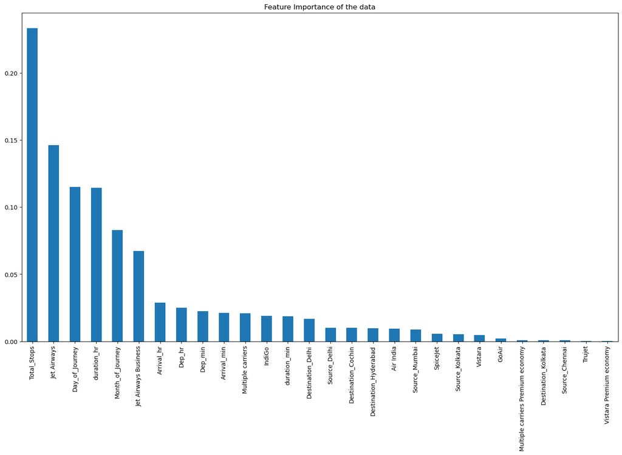

```python
pd.Series(Et.feature_importances_,index=x.columns).sort_values(ascending=False).plot(kind='bar',figsize=(18,10))
plt.title('Feature Importance of the data')
plt.savefig('Feature Importance of the data.png')
plt.show()
```

**Splitting the dependent variable & independent variable into training and test dataset using train test split**

```python
x_train,x_test,y_train,y_test=train_test_split(x,y,test_size=0.3,random_state=44)
```

**Fitting the Extra Tree Regressor model with the train dependent and train independent variable and getting the r2 Score between the predicted value and dependent test dataset**

```python
ET_Model=ExtraTreesRegressor(n_estimators=120)
ET_Model.fit(x_train,y_train)
y_predict=ET_Model.predict(x_test)
r2_score(y_test,y_predict)
```

```
0.7888532195026406
```

**Fitting the Random Forest Regressor model with the train dependent and train independent variable and getting the r2 Score between the predicted value and dependent test dataset**

```python
RF_Model=RandomForestRegressor()
RF_Model.fit(x_train,y_train)
y_predict=RF_Model.predict(x_test)
r2_score(y_test,y_predict)
```

```
0.8050827210771141
```

**Fitting The Random Forest Regressor Model with the list of parameters in the RandomizedSearchCV Algorithm and getting the r2 Score between the predicted value and dependent test dataset**

```python
n_estimators = [int(x) for x in np.linspace(start = 80, stop = 1500, num = 10)]
max_features = ['auto', 'sqrt']
max_depth = [int(x) for x in np.linspace(6, 45, num = 5)]
min_samples_split = [2, 5, 10, 15, 100]
min_samples_leaf = [1, 2, 5, 10]

rand_grid={'n_estimators': n_estimators,
               'max_features': max_features,
               'max_depth': max_depth,
               'min_samples_split': min_samples_split,
               'min_samples_leaf': min_samples_leaf}
rf=RandomForestRegressor()

rCV=RandomizedSearchCV(estimator=rf,param_distributions=rand_grid,scoring='neg_mean_squared_error',
                       n_iter=10,cv=3,random_state=42, n_jobs = 1)

rCV.fit(x_train,y_train)
rf_pred=rCV.predict(x_test)
r2_score(y_test,rf_pred)
```

```
0.8115715357392459
```

**Getting the Mean Absolute Error and Mean Squared Error values between the predicted value from the RandomizedSearchCV and dependent test dataset.**

```python
print('MAE',mean_absolute_error(y_test,rf_pred))
print('MSE',mean_squared_error(y_test,rf_pred))
```

```
MAE 1197.2359764535358
MSE 4065975.582818873
```

**Fitting the CatBoost Regressor model with the train dependent and train independent variable and getting the r2 Score between the predicted value and dependent test dataset**

```python
cat=CatBoostRegressor()
cat.fit(x_train,y_train)
cat_pred=cat.predict(x_test)
r2_score(y_test,cat_pred)
```

[output not shown]

[output cut: 946 more lines]

[output not shown]

```
0.8666885394466252
```

_**Changing the data type of the duration_hr , duration_min column from "object" to "int"**_

```python
x_train[['duration_hr','duration_min']]=x_train[['duration_hr','duration_min']].astype(int)
x_test[['duration_hr','duration_min']]=x_test[['duration_hr','duration_min']].astype(int)
```

**Fitting the LGBM Regressor model with the train dependent and train independent variable and getting the r2 Score between the predicted value and dependent test dataset**

```python
lgb=LGBMRegressor()
lgb.fit(x_train,y_train)
lgb_pred=lgb.predict(x_test)
r2_score(y_test,lgb_pred)
```

```
0.8162294925874082
```

**Fitting the XGB Regressor model with the train dependent and train independent variable and getting the r2 Score between the predicted value and dependent test dataset**

```python
xgb=XGBRegressor()
xgb.fit(x_train,y_train)
xgb_pred=xgb.predict(x_test)
r2_score(y_test,xgb_pred)
```

```
0.8475815935971374
```

*Fitting the EXtra Tree Regressor model with the train dependent and train independent variable and getting the r2 Score between the predicted value and dependent test dataset*

```python
Et2=ExtraTreesRegressor()
Et2.fit(x_train,y_train)
Et2_pred=Et2.predict(x_test)
r2_score(y_test,Et2_pred)
```

```
0.7875423285231675
```

**Create the pickle file of the model with the highest r2 score with the model name**

```python
pickle.dump(cat,open('Predictive model.pkl','wb'))
```

**Loading the pickle file**

```python
model=pickle.load(open('Predictive model.pkl','rb'))
```

**Predicting the Price of test data using the loaded pickle file**

```python
prediction=model.predict(df_test)
```

**Making the Predicted value as a new dataframe and concating it with test data**

```python
prediction_df=pd.DataFrame(prediction,columns=['Predicted Price(Approx.)'])
pred_df=pd.concat([df_test,prediction_df],axis=1)
```

**Exporting the Test Data With Price to a csv file**

```python
pred_df.to_csv('Prediction Flight Price.csv',index=False)
```